# DATA3888 Final Report

Word Count: 3000 Words

Optiver 10 | SID: 500505430, 500505359, 500178979, 500483253, 510523202, 500000463

Submission Date: 28/5/2023

# 1 Executive Summary

```r
# Read in pre-processed results
results = read.csv('./cache/data_results.csv')
new_df = results[c("RMSE_EWMA", "RMSE_LinReg", "RMSE_Armagarch", "RMSE_Hisvol", "RMSE_Lingarch", 'Cluster')][-1,]
colnames(new_df) = c("EWMA", "LinRegression", "ArmaGarch", "HisvolGarch", "RegressionGarch", 'Cluster')
# Ensure all columns are numeric
new_df$EWMA = as.numeric(new_df$EWMA)
new_df$LinRegression = as.numeric(new_df$LinRegression)
new_df$ArmaGarch = as.numeric(new_df$ArmaGarch)
new_df$HisvolGarch = as.numeric(new_df$HisvolGarch)
new_df$RegressionGarch = as.numeric(new_df$RegressionGarch)

# Remove cluster column
new_df_plot = subset(new_df, select = -c(Cluster) )
new_df_plot = na.omit(new_df_plot)

means = sapply(new_df_plot, mean)
stdevs = sapply(new_df_plot, sd)
ratios = sapply(new_df_plot, mean)/sapply(new_df_plot, sd)

# Conduct 1-sided t-tests vs linear regression to test for significance in RMSE values
ewma_t_test = t.test(new_df$EWMA, new_df$LinRegression, alternative='less')$p.value
ArmaGarch_t_test = t.test(new_df$ArmaGarch, new_df$LinRegression,alternative='less')$p.value
HisvolGarch_t_test = t.test(new_df$HisvolGarch, new_df$LinRegression, alternative='less')$p.value
RegressionGarch_t_test = t.test(new_df$RegressionGarch, new_df$LinRegression,alternative='less')$p.value

t_test_results = data.frame(P_Value=c(ewma_t_test, ArmaGarch_t_test, HisvolGarch_t_test, RegressionGarch_t_test, NA))
rownames(t_test_results) = c('EWMA', 'ARMA_GARCH', 'HisvolGARCH', 'Regression-GARCH', 'LinearRegression')

dat = data.frame("RMSE Mean" = means,
                 "RMSE Stdev" = stdevs,
                  "p-Value" = c(ewma_t_test, NA, ArmaGarch_t_test, HisvolGarch_t_test, RegressionGarch_t_test)
)

# Visualise in a table
kable(dat, caption="RMSE Mean, RMSE Standard Deviation and p-Value per Model") |>
  kable_classic(
    full_width = T,
    html_font = "Computer Modern",
    font_size = 14
  ) %>%
  kable_styling(bootstrap_options = c("striped", "hover"))
```

RMSE Mean, RMSE Standard Deviation and p-Value per Model

|  | RMSE.Mean | RMSE.Stdev | p.Value |
| --- | --- | --- | --- |
| EWMA | 0.0001609 | 5.61e-05 | 0.0227761 |
| LinRegression | 0.0001767 | 6.13e-05 | NA |
| ArmaGarch | 0.0002222 | 5.83e-05 | 1.0000000 |
| HisvolGarch | 0.0001784 | 6.04e-05 | 0.5806300 |
| RegressionGarch | 0.0001692 | 5.35e-05 | 0.1661822 |

*Figure 1: Final Results*

# 2 Background & Aim

High-frequency trading (HFT) is a sophisticated algorithmic trading approach that leverages high frequency order book data and advanced predictive modelling techniques. By executing a substantial volume of trades on a daily basis, HFT strategies aim to capitalise on real-time market inefficiencies (Jones, 2013). HFT strategies, though executed in financial markets, lean heavily on data science models and analysis, requiring interdisciplinary focus.

Optiver is one such player in the market, specialising in the trading of equity derivatives, utilising the relation between volatility and option prices. Volatility is a statistical measure of the extent to which the price or returns of a financial asset fluctuate over a specific period of time, indicating the level of uncertainty or risk associated with the asset (Daly, 2008). As a key component of the Black-Scholes option pricing formula (Black & Scholes, 1973), whilst imperfect, its extensive use by trading firms implies a positive correlation between volatility and options pricing (Boffetti, 2016).

In the trading industry, success is contingent on model predictive power and interpretability of the model for the traders. This is particularly true in the case of volatility, where “0.1-0.4 cents of value exist for traders if they could exclude the uncertainty brought by volatility less than two seconds earlier.” (Meng et al, 2022). Given the dynamic nature of trading, possessing a comprehensive understanding of the model’s prediction process becomes essential for effective model utilisation by the trader.

The key question at the heart of this report is: “What is the ‘best’ model in terms of practicability?”. This project thus aims to investigate the trade-off between predictive power and interpretability, and assess the performance of a variety of ultra-high frequency volatility predictors. Each volatility model is assessed in 3 categories: firstly predictive power, the general accuracy of prediction for each model; stability, the consistency of model output; and lastly simplicity or ease of comprehension, referring to how easy to understand the target audience, traders may find the model to be. Ultimately these different evaluation strategies would determine the most optimal volatility predictor for a trader to use.

# 3 Approach

## 3.1 Data Collection

Our data was pre-collected and provided by Optiver. This consisted of 112 unidentified stocks, grouped into 3821 non-consecutive 600 second time intervals. Price and size were given for each of the bid and asks sides of the order book for each second in the 600-second interval that a trade was made. The number in the bid/ask price is the ‘level’ of the price, ie. 1 is the best bid/ask, whilst 2 is the second best bid/ask price in the order book at that moment in time. Price was normalised around 1 already, and all NAs removed. An example of the data is seen below in figure 2.

```r
stock0 = read.csv('./cache/individual_book_train/stock_0.csv')
stock0 = subset(stock0, select = -c(stock_id) )

kable(head(stock0, 3), escape = FALSE, caption="Snapshot of Stock Data") |>
  kable_classic(
    full_width = T,
    html_font = "Computer Modern",
    font_size = 14
  ) %>%
  kable_styling(bootstrap_options = c("striped", "hover"))
```

Snapshot of Stock Data

| time_id | seconds_in_bucket | bid_price1 | ask_price1 | bid_price2 | ask_price2 | bid_size1 | ask_size1 | bid_size2 | ask_size2 |
| --- | --- | --- | --- | --- | --- | --- | --- | --- | --- |
| 5 | 0 | 1.001422 | 1.002301 | 1.00137 | 1.002353 | 3 | 226 | 2 | 100 |
| 5 | 1 | 1.001422 | 1.002301 | 1.00137 | 1.002353 | 3 | 100 | 2 | 100 |
| 5 | 5 | 1.001422 | 1.002301 | 1.00137 | 1.002405 | 3 | 100 | 2 | 100 |

*Figure 2: Stock_0 Data Snapshot*

## 3.2 Exploration

To investigate the potential for clustering, exploratory data analysis (EDA) was initiated. During this process, we randomly sampled ten-minute intervals to calculate volatility for all stocks. The findings (Appendix 9.3) showed a sampling bias, with lower volatility stocks over-represented and higher volatility stocks under-represented. The motivation for clustering extends beyond sampling bias, as utilising clustering can capture stocks with common risk characteristics and volatility patterns (Bjärkby & Grägg, 2019). Given the availability of volatility and size features present in the dataset, we developed an innovative clustering method to guide the development of an optimal model for stocks with different volatility and liquidity profiles.

20 randomly selected time IDs were used to calculate average volatility and volume across all stocks. These 40 features were then used to cluster the stocks via k-means, with 5 centroids determined to be optimal. Three or four were deemed too small due to outliers in the data allocating just 1 or 2 stocks to a single cluster, whilst more than 5 dispersed the data too much for accurate analysis.

This resulted in 54 stocks in cluster 1, 18 stocks in cluster 2, 1 stock in cluster 3, 37 stocks in cluster 4, and 2 stocks in cluster 5. Though outliers are still significant when trading financial instruments as they represent real datapoints, focus remained on clusters 1, 2 and 4 due to their much more substantial sample size.

## 3.3 Model Development

To develop an optimal volatility predictor for traders, five models were developed for analysis. This analysis focuses on the development of statistical models due to their greater ease of interpretability over machine learning models (frequent black box nature, non-linearity and lack of assumptions) (Velido et al., 2012). The five models developed for analysis and testing were: regression, exponentially weighted moving average (EWMA), ARMA-GARCH, HISVOL-GARCH and Regression-GARCH.

### 3.3.1 Regression model

A simple linear regression against log returns was used as a baseline as comparison. This is what Optiver currently uses, with the simplicity and robustness of a regression model makes it a logical choice to serve as the baseline model for performance.

### 3.3.2 EWMA model

For volatility predictions, a historical volatility series for a given stock is inputted into the EWMA model. For each time point, a EWMA is computed based on the EWMA of previous time points and the value of current time point, giving greatest value to the most recent reading, and exponentially decaying previous readings.
$$EWMA_t = \lambda \times \sigma_t + (1- \lambda) \times EWMA_{t-1}$$
Our EWMA decayed at a rate of $\frac{2}{n+1}$. As this only produces a single data point and we are forecasting a 30 second volatility horizon, this prediction was flatlined to extend across the full 30 second window.

### 3.3.3 ARMA-GARCH model

The ARMA-GARCH framework is a modern statistical-based volatility forecasting model. GARCH models have increased propensity to capture the observed patterns and nature of financial market data, in comparison to the two aforementioned models. The ARMA component is a combination of both autoregressive (AR) and moving average (MA) models, encompassing both market momentum and mean reverting effects. The GARCH component accommodates for the observed phenomenon of volatility clustering (Mandelbrot, 1967), by allowing for the conditional variance to be time-varying and dependent on past squared errors or residuals. Additionally, the model’s ability to accommodate for non-normal distributions provides value in modelling the well-documented fat-tailed distributions of financial data (Poon & Granger, 2003).

The ARMA-GARCH model was implemented using the ARMA(1,1) and GARCH(1,1) models, applying logarithmic returns and volatility as the independent and dependent variables respectively.

### 3.3.4 HISVOL-GARCH model

The HISVOL-GARCH model is an innovative variant of the GARCH model, combining the historical volatility (HISVOL) and ARMA-GARCH models using a weight parameter (lambda) of 0.5.

The HISVOL component is calculated by computing the average volatility over the input data set.

$$hisvol\_garch\_forecast = \lambda \times hisvol\_forecast + (1 -
\lambda) \times garch\_forecast$$
This model amalgamates the strengths of both HISVOL and ARMA-GARCH models, delivering a more holistic and accurate volatility estimation. Coupled with the aforementioned benefits of the ARMA-GARCH model, it places an increased emphasis on the mean reverting nature of volatility (Merville & Pieptea, 1989) by incorporating the HISVOL model.

### 3.3.5 Regression-GARCH Model

The second composite innovation is the Regression-GARCH model. It combines both the baseline regression model and ARMA-GARCH models, with equal weighting to achieve an aggregated prediction. This innovation was constructed as, in early visualisations, it was noticed that linear regression often predicted volatility above where it was realised, and ARMA-GARCH below, thus this weighting attempted to minimise uncorrelated errors in the models.

### 3.3.6 Evaluation Framework

Our evaluation strategies are quantitative-based to assess predictive power and stability, but qualitative in measuring model simplicity, with equal weighting to each of these three categories given for final evaluation.

RMSE was used for accuracy and seen as more robust than other measures such as $R^2$ due to its relation to core model error.

Standard deviation of model RMSEs across time IDs were used to judge stability, with lower standard deviation demonstrating overall improved predictive power.

Simplicity was evaluated via a student survey. Due to access limitations, students were chosen as a proxy variable. The survey detailed a brief explanation on each model using simple accessible language. The respondent is asked to rank how easy they found each model to be from 1 to 5, 1 being ‘most simple’ and 5 being ‘most complex/difficult’.

Rank aggregation method was then used to aggregate the responses given into one most optimal ranking representing the ‘average’ perception of each model’s relative simplicity. A score is assigned to each model based on their performance in accuracy, stability and simplicity, in which 1 represents best performing and 5 represents worst performing. The model with the lowest mean score would be the best performing model.

# 4 Results

We note that EWMA results differ compared to our presentation due to an error being detected in how EWMA RMSE is calculated between then and now. All processes remained the same, and were fairly applied to come to our below conclusions.

## 4.1 Accuracy

In the final results below, each model’s average RMSEs per cluster were aggregated and generalised into one mean RMSE score for overall performance.

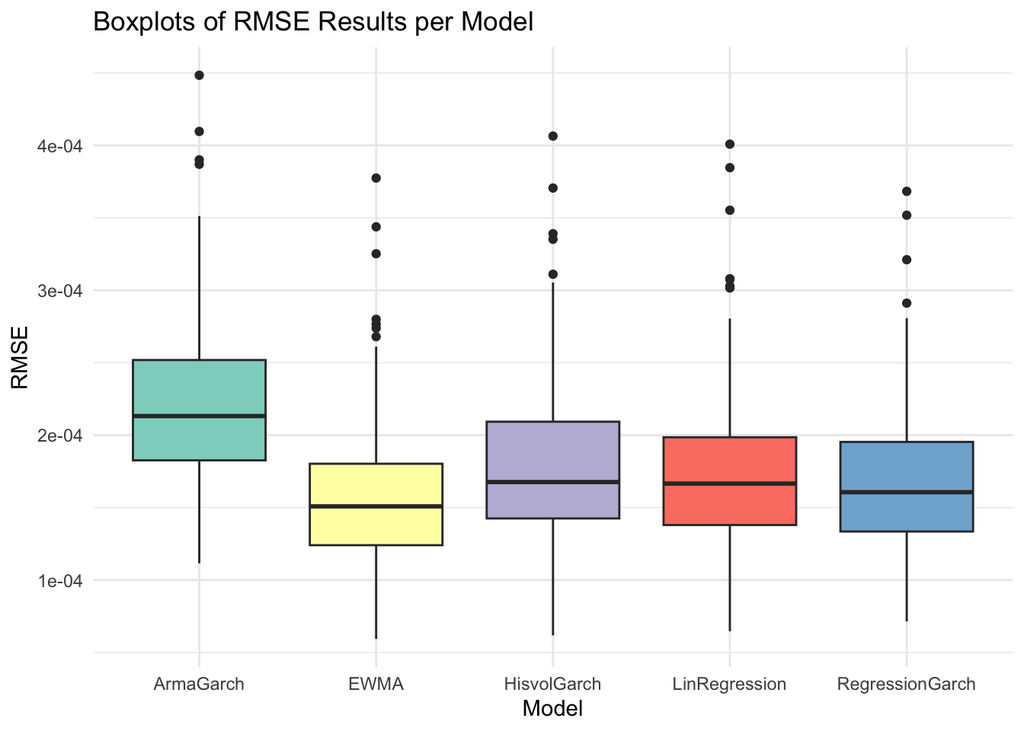

```r
results = read.csv('./cache/data_results.csv')
new_df = results[c("RMSE_EWMA", "RMSE_LinReg", "RMSE_Armagarch", "RMSE_Hisvol", "RMSE_Lingarch", 'Cluster')][-1,]
colnames(new_df) = c("EWMA", "LinRegression", "ArmaGarch", "HisvolGarch", "RegressionGarch", 'Cluster')

new_df$EWMA = as.numeric(new_df$EWMA)
new_df$LinRegression = as.numeric(new_df$LinRegression)
new_df$ArmaGarch = as.numeric(new_df$ArmaGarch)
new_df$HisvolGarch = as.numeric(new_df$HisvolGarch)
new_df$RegressionGarch = as.numeric(new_df$RegressionGarch)

new_df_plot = subset(new_df, select = -c(Cluster) )
new_df_plot = na.omit(new_df_plot)
# Reshape your data from wide to long format
df_long <- new_df_plot %>%
  pivot_longer(everything(), names_to = "Model", values_to = "value")


# Create boxplot
ggplot(df_long, aes(x = Model, y = value, fill=Model)) +
  geom_boxplot() +
  theme(axis.text.x = element_text(angle = 45, hjust = 1)) +
  labs(title = "Boxplots of RMSE Results per Model",
       x = "Model",
       y = "RMSE") +
  scale_fill_brewer(palette = "Set3") +
  theme_minimal() + # Minimalistic theme
  theme(legend.position = "none")
```

```r
#ggsave("boxplot.png", plot = p, width = 10, height = 5)
```

*Figure 3: Model RMSE Performance*

The final ranking of models from lowest average RMSE to highest is as follows:

1. EWMA
2. Regression-GARCH
3. Linear Regression
4. Hisvol-GARCH
5. ARMA-GARCH

## 4.2 Stability

Comparing the standard deviation of RMSE for different predictive models across the clusters, a lower standard deviation implies that the model’s predictions are more consistent and thus more stable.

The final ranking of models from lowest standard deviation to highest is as follows:

1. Regression-GARCH
2. EWMA
3. ARMA-GARCH
4. Hisvol-GARCH
5. Linear Regression

The Regression-GARCH model appears to be the most stable, demonstrating the most consistent performance across different clusters. The linear regression model, however, shows the highest variation in its predictive performance, suggesting that it’s the least stable model among these. The only exception is cluster 5, however this is discounted due to the fact this cluster only contains 2 data samples.

Additionally, the Regression-GARCH model showcases the best standard deviation values in Cluster 2 and Cluster 4, both of which have a relatively high number of samples. This fact is significant because models’ performance in areas with a larger amount of data can greatly influence the overall predictive reliability and accuracy.

## 4.3 Simplicity

As seen below, the EWMA model and Linear Regression model tend to be perceived as more simple, dominating 1st and 2nd preference. Conversely, the HISVOL-GARCH and Regression-GARCH models tend to be perceived as being more complex, as a greater portion of responses designate them as 4th and 5th in ranking. The GARCH model seems to also be perceived as a simpler model, although less so than the EWMA and GARCH models, with its most common ranking being 3rd.

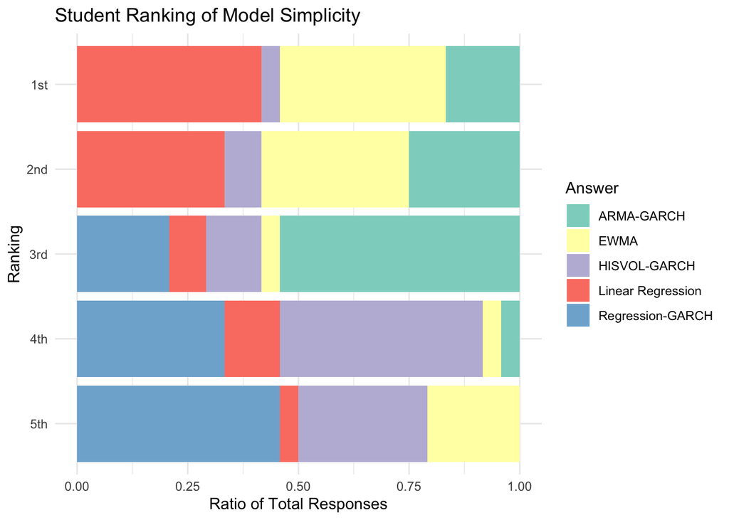

```r
mydata = read.csv("./cache/survey_responses_five_models.csv", sep=',', header=FALSE)
mydata <- mydata[-1,]

# aggregate the existing dataframe;
data_v = mydata %>%
  gather(key=items, value=Answer) %>% mutate(Answer=factor(Answer),
                                             items=factor(items))

ggplot(data_v, aes(x=items)) +
  geom_bar(aes(fill=Answer),position="fill") +
  coord_flip() +
  scale_x_discrete(limits=rev(levels(data_v$items)),
                    name="Ranking",
                   labels=c("5th", "4th","3rd","2nd","1st")) +
  scale_y_continuous(name="Ratio of Total Responses") +
  ggtitle("Student Ranking of Model Simplicity") -> p1
p1 + scale_fill_brewer(palette="Set3") + theme_minimal()
```

*Figure 4: Survey Distribution*

Through use of Spearman rank aggregation to process the survey results, the overall ranking of model simplicity is as such:

1. Linear Regression
2. EWMA
3. ARMA-GARCH
4. HISVOL-GARCH
5. Regression-GARCH

Following expectations, both composite models of HISVOL-GARCH and Regression-GARCH were ranked as being more complex in comparison to the other models. The model most commonly perceived as being simple being the regression model also matches literature and expectations of it being simple and intuitive as a common candidate for baseline model.

## 4.4 Overall results

```r
results = read.csv('./cache/data_results.csv')
new_df = results[c("RMSE_EWMA", "RMSE_LinReg", "RMSE_Armagarch", "RMSE_Hisvol", "RMSE_Lingarch", 'Cluster')][-1,]
colnames(new_df) = c("EWMA", "LinRegression", "ArmaGarch", "HisvolGarch", "RegressionGarch", 'Cluster')
# Ensure all columns are numeric
new_df$EWMA = as.numeric(new_df$EWMA)
new_df$LinRegression = as.numeric(new_df$LinRegression)
new_df$ArmaGarch = as.numeric(new_df$ArmaGarch)
new_df$HisvolGarch = as.numeric(new_df$HisvolGarch)
new_df$RegressionGarch = as.numeric(new_df$RegressionGarch)

new_df_plot = subset(new_df, select = -c(Cluster) )
new_df_plot = na.omit(new_df_plot)

# Rank the mean and stdev of RMSE
means = sapply(new_df_plot, mean)
means_ranked = rank(means)
stdevs = sapply(new_df_plot, sd)
stdevs_ranked = rank(stdevs)

# Rank the survey data through RankAggreg
mydata = read.csv("./cache/survey_responses_five_models.csv", sep=',', header=FALSE)
mydata <- mydata[-1,]
response_matrix <- as.matrix(mydata)
answer <- RankAggreg(x=response_matrix, k=5, method="CE", distance="Spearman", verbose = FALSE)
ranks_simple = data.frame(t(data.frame(ranks=rank(answer$top.list))))
colnames(ranks_simple) = answer$top.list
r_dat = c(ranks_simple$EWMA,ranks_simple$`Linear Regression`, ranks_simple$`ARMA-GARCH`,
          ranks_simple$`HISVOL-GARCH`, ranks_simple$`Regression-GARCH`)

# Combine all ranked data
ranked_data = (data.frame(Accuracy=means_ranked, Stability=stdevs_ranked))
ranked_data$Simplicity = r_dat
#ranked_data = data.frame(Accuracy=means_ranked, Stability=stdevs_ranked, Simplicity=c(2,1,3,4,5))
ranked_data$Overall_Ranking = round(rowMeans(ranked_data), 2)
ranked_data = ranked_data %>% arrange(Overall_Ranking)

kable(ranked_data, escape = FALSE, caption="Final Ranked Results") |>
  kable_classic(
    full_width = T,
    html_font = "Computer Modern",
    font_size = 14
  ) %>%
  kable_styling(bootstrap_options = c("striped", "hover"))
```

Final Ranked Results

[output not shown]

*Figure 5: Final Result Ranking*

Based on the ranking of each model’s performance in accuracy, stability and simplicity, scores between 1 (best performing) and 5 (worst performing) were assigned.

All models had strong predictive power, with RMSEs divided by underlying standard deviations in volatility well below 1 across all clusters, representing ability to capture variance through predictions (Appendix 9.7).

# 5 Shiny App

Our app (located in the github repository due to file size constraints) was delivered in two parts. The first Shiny app contained two visualisations: a scatter plot demonstrating the spread of stocks from each cluster via their volatility and volume features, and a scatter plot showing the distribution of model performance on each stock as separated by clusters. For the first plot, users could select the group of stocks that will be shown on the plot from the options of low, medium, high clusters. For the second plot, users can select which model performances to view across the clusters. This visualisation aids the user in forming a considered understanding into the relative accuracy and stability of models across clusters.

The second Shiny app is an interactive time-series forecast that demonstrates the relative performance of models under different parameters (Appendix 9.8). Presenting historical volatility training data as well as volatility for testing data and model forecasts, users can select parameters such as training size and prediction horizon and view its effect on the accuracy of each model’s predictions. We chose to provide this visualisation to show how each model forms predictions from training data in a way that is simple and accessible for traders.

# 6 Discussion & Conclusion

The models used in this project are largely limited. Although the GARCH family models are outperformed by the EWMA model in this study, it is unknown if this will be the case for other models from the GARCH family. For example, according to El Jebari & Hakmaoui’s 2018 study, the IGARCH model exceeds the EWMA model when predicting volatility for the Moroccan Stock Exchange Market. In future work, more models could be explored.

The use of third-party data collection introduces a potential limitation regarding the representativeness of the sample. The presence of a sampling bias could adversely affect the generalisability of overall analysis, as certain stocks may be over or under-represented. Consequent to potential limited stock coverage, the opportunity is opened to investigate clustering techniques to assess representativeness and identity subgroups - mitigating the potential impact of sampling bias. In future opportunities to further minimise the possibility of sampling bias, we could collect the data ourselves.

There is also the issue regarding measurement of simplicity. The sample pool is extremely small, comprising 24 respondents who are students instead of traders. There is a gap between the knowledge which these two groups possess. In future work it may be more valuable to gather results from traders themselves, or at least through a better proxy variable for estimation. The number of samples taken should also be increased.

Ultimately there were no significant differences in model performance regarding different clusters, as the results were quite consistent. Future work may be required to determine whether or not this was due to issues regarding the clustering.

To summarise, this study found that the EWMA model is generally the best model due to its comparative simplicity, as well as its high accuracy and stability in outputting predictions for the provided order book data from Optiver. Due to the limitations in the project as stated above, this result is best interpreted in regards to the data provided. It is neither conclusive nor comprehensive. Nevertheless, we believe these results may serve as a guideline for traders in choosing the forecast model ideal for their purposes.

# 7 Student Reflection

Ethan and Mitchell provided background information given finance degree knowledge, with Jennifer doing further literature review. Ethan analysed, pre-processed and clustered data, before Mitchell, Jennifer, Garry and Jason created the models. Ethan then trained all models and extracted results. Once these results were processed, Ethan, Mitchell and Jennifer created result visualisations and performed results analysis. Jennifer setup, conducted and analysed survey results. Mitchell created the Shiny app for model performance. Jason, Haoran and Garry created the shiny app to show distribution of data clustering and RMSE of different models. Mitchell and Jennifer wrote the report body whilst Ethan created the presentation, and constructed the visualisations and formatting for the report.

# 8 References

Boffetti, M. (2016). Option Volatility & Arbitrage Opportunities. Louisiana State University and Agricultural & Mechanical College.

Bjärkby, S., & Grägg, S. (2019). A Cluster Analysis of Stocks to Define an Investment Strategy. Royal Institute of Technology.

Black, F., & Scholes, M. (1973). The Pricing of Options and Corporate Liabilities. Journal of Political Economy, 81(3), 637–654. http://www.jstor.org/stable/1831029

Daly, K. (2008). Financial volatility: Issues and measuring techniques. Physica A: statistical mechanics and its applications, 387(11), 2377-2393.

El Jebari, O., & Hakmaoui, A. (2018). GARCH Family Models vs EWMA: Which is the Best Model to Forecast Volatility of the Moroccan Stock Exchange Market? Revista de Metodos Cuantitativos Para La Economia y La Empresa.

Exponentially Weighted Moving Average (EWMA). (2021). Corporate Finance Institute. https://corporatefinanceinstitute.com/resources/capital-markets/exponentially-weighted-moving-average-ewma/

Grübe, M. (2019). Intraday volatility forecasting in high-frequency data using order book information (Doctoral dissertation).

Jones, C. M. (2013). What do we know about high-frequency trading?. Columbia Business School Research Paper, (13-11).

Mandelbrot, B. (1967). The Variation of Some Other Speculative Prices. The Journal of Business, 40(4), 393–413. http://www.jstor.org/stable/2351623

Meng, K., Li, S., & Cooper, R. (2022). The interaction between volatility and high frequency trading. Procedia Computer Science, 202, 354–359. https://doi.org/10.1016/j.procs.2022.04.048

Merville, L. J., & Pieptea, D. R. (1989). Stock-price volatility, mean-reverting diffusion, and noise. Journal of Financial Economics, 24(1), 193-214.

Poon, S.H., & Granger. C.W.J. (2003). Forecasting Volatility in Financial Markets: A Review. Journal of Economic Literature, 41(2), 478–539. http://www.jstor.org/stable/3216966

Vellido, A., Martín-Guerrero, J., & Lisboa, P. (2012). Making machine learning models interpretable. https://citeseerx.ist.psu.edu/document?repid=rep1&type=pdf&doi=ce0b8b6fca7dc089548cc2e9aaac3bae82bb19da

Zhang, L., Mykland, P. A., & Ait-Sahalia, Y. (2005). A Tale of Two Time Scales: Determining Integrated Volatility With Noisy High-Frequency Data. Journal of the American Statistical Association.

# 9 Appendix

## 9.1 Github Link

The below link contains all ‘cached’ data used throughout this report, the Shiny App code, as well as all of the code both seen below and used for the processing and exploration of the data. https://github.sydney.edu.au/lgen6971/DATA3888_Optiver10

## 9.2 Clustering Visualisation

Clustering was used in an attempt to find best models for different features of stocks. However, given the large dimension of features used (40), it is hard to visualise, and further investigation is likely required to determine if this was a useful data analysis feature, given that it did not impact our final results or conclusion.

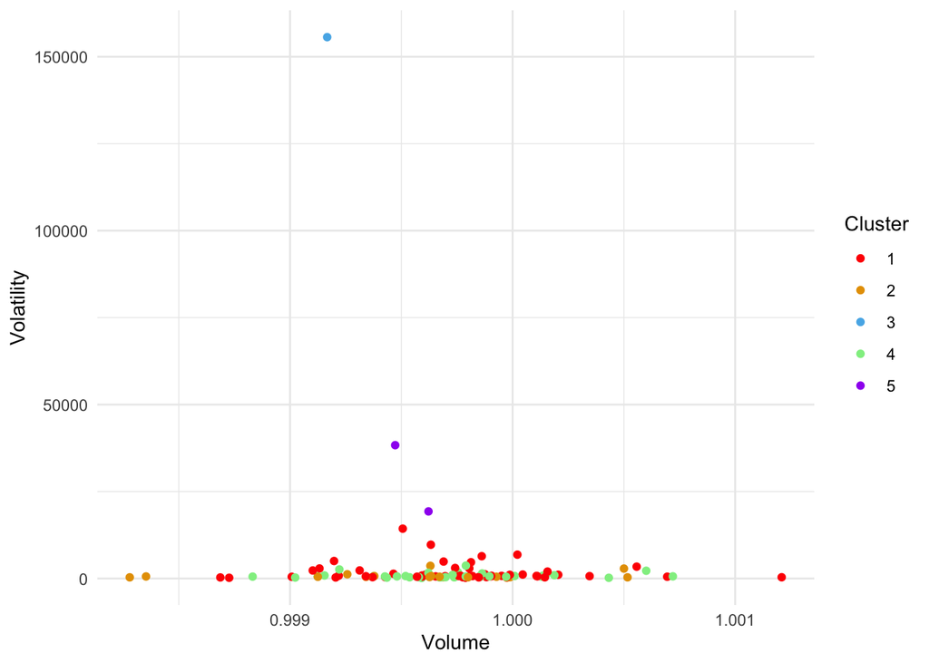

```r
data_to_cluster = read.csv('./cache/clustering_results.csv')
#a = data_to_cluster[c('Cluster', paste0('Volatility', 1:40), paste0('Volume', 1:40))]
vol_avgs = rowMeans(data_to_cluster[c(paste0('Volatility', 1:40))])
volume_avgs = rowMeans(data_to_cluster[c(paste0('Volume', 1:40))])
f = data.frame(stock=data_to_cluster$X, Cluster=as.character(data_to_cluster$Cluster), Volatility=vol_avgs, Volume=volume_avgs)
ggplot(f, aes(x=Volume, y=Volatility, color=Cluster)) +
  geom_point() +
  scale_color_manual(values=c('red','#E69F00', '#56B4E9', 'lightgreen', 'purple')) +
  scale_fill_brewer(palette = "Set3") +
  theme_minimal()
```

## 9.3 Volatility Sample

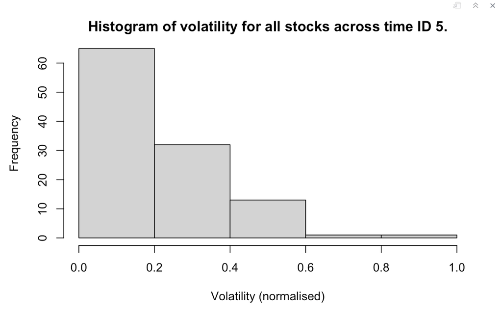

Volatility Sample

## 9.4 Per-Cluster Results

Per-cluster results for overal RMSE and stability (stdev of RMSE) are seen below:

```r
cluster_rmse_avg = new_df %>%
    group_by(Cluster) %>%
    summarise_all("mean")

  min_values <- cluster_rmse_avg |>
  mutate(across(where(is.numeric), round, 7)) |>
  select(-Cluster) |>
  purrr::pmap(pmin, na.rm = TRUE) |>
  as.numeric() |>
  na.omit()

cluster_rmse_avg |>
  mutate(across(where(is.numeric), round, 7)) |>
  mutate(across(-Cluster, ~ if_else(row_number() %in% which(.x %in% min_values),
    cell_spec(.x,
      format = "html",
      color = "darkgreen", bold = TRUE
    ), as.character(.x)
  ))) |>
  mutate(across(everything(), ~ ifelse(.x == "NaN", "", .))) |>
  kable(escape = FALSE, caption="Results per cluster, RMSE averages") |>
  kable_classic(
    full_width = T,
    html_font = "Computer Modern",
    font_size = 14
  ) %>%
  kable_styling(bootstrap_options = c("striped", "hover"))
```

Results per cluster, RMSE averages

| Cluster | EWMA | LinRegression | ArmaGarch | HisvolGarch | RegressionGarch |
| --- | --- | --- | --- | --- | --- |
| 1 | 0.0001438 | 0.0001586 | 0.0001994 | 0.0001598 | 0.000151 |
| 2 | 0.0002178 | 0.0002379 | 0.0002855 | 0.0002388 | 0.0002248 |
| 3 | 0.0002404 | 0.0002623 | 0.0003031 | 0.0003054 | 0.0002552 |
| 4 | 0.000157 | 0.000172 | 0.0002217 | 0.0001734 | 0.0001669 |
| 5 | 0.0001444 | 0.0001581 | 0.0002384 | 0.0001642 | 0.0001618 |

```r
cluster_rmse_sd = new_df %>%
    group_by(Cluster) %>%
    summarise_all("sd")

  min_values <- cluster_rmse_sd |>
  mutate(across(where(is.numeric), round, 7)) |>
  select(-Cluster) |>
  purrr::pmap(pmin, na.rm = TRUE) |>
  as.numeric() |>
  na.omit()

cluster_rmse_sd |>
  mutate(across(where(is.numeric), round, 7)) |>
  mutate(across(-Cluster, ~ if_else(row_number() %in% which(.x %in% min_values),
    cell_spec(.x,
      format = "html",
      color = "darkgreen", bold = TRUE
    ), as.character(.x)
  ))) |>
  mutate(across(everything(), ~ ifelse(.x == "NaN", "", .))) |>
  kable(escape = FALSE, caption="Results per cluster, RMSE standard deviation") |>
  kable_classic(
    full_width = T,
    html_font = "Computer Modern",
    font_size = 14
  ) %>%
  kable_styling(bootstrap_options = c("striped", "hover"))
```

Results per cluster, RMSE standard deviation

| Cluster | EWMA | LinRegression | ArmaGarch | HisvolGarch | RegressionGarch |
| --- | --- | --- | --- | --- | --- |
| 1 | 4.38e-05 | 4.84e-05 | 4.08e-05 | 4.63e-05 | 4.11e-05 |
| 2 | 6.48e-05 | 6.96e-05 | 6.43e-05 | 6.44e-05 | 6.01e-05 |
| 3 | NA | NA | NA | NA | NA |
| 4 | 5.14e-05 | 5.69e-05 | 5.56e-05 | 5.76e-05 | 4.88e-05 |
| 5 | 1.2e-06 | 8e-07 | 2.3e-06 | 2.3e-06 | 1.8e-06 |

## 9.5 Per Cluster Significance Tests

One-sided Welch t-tests were conducted to test statistical significance for models against the linear regression base line, with the null hypothesis that the RMSE of the two models is the same.

```r
#t.test(new_df$EWMA, new_df$LinRegression, alternative='less')$p.value
cluster_1_test = new_df %>% filter(Cluster==1)
c1_ewma = t.test(cluster_1_test$EWMA, cluster_1_test$LinRegression, alternative='less')$p.value
c1_garch = t.test(cluster_1_test$ArmaGarch, cluster_1_test$LinRegression, alternative='less')$p.value
c1_hisvol = t.test(cluster_1_test$HisvolGarch, cluster_1_test$LinRegression, alternative='less')$p.value
c1_regarch = t.test(cluster_1_test$RegressionGarch, cluster_1_test$LinRegression, alternative='less')$p.value
c1_pvals = c(c1_ewma, c1_garch, c1_hisvol, c1_regarch)

cluster_2_test = new_df %>% filter(Cluster==2)
c2_ewma = t.test(cluster_2_test$EWMA, cluster_2_test$LinRegression, alternative='less')$p.value
c2_garch = t.test(cluster_2_test$ArmaGarch, cluster_2_test$LinRegression, alternative='less')$p.value
c2_hisvol = t.test(cluster_2_test$HisvolGarch, cluster_2_test$LinRegression, alternative='less')$p.value
c2_regarch = t.test(cluster_2_test$RegressionGarch, cluster_2_test$LinRegression, alternative='less')$p.value
c2_pvals = c(c2_ewma, c2_garch, c2_hisvol, c2_regarch)

cluster_4_test = new_df %>% filter(Cluster==4)
c4_ewma = t.test(cluster_4_test$EWMA, cluster_4_test$LinRegression, alternative='less')$p.value
c4_garch = t.test(cluster_4_test$ArmaGarch, cluster_4_test$LinRegression, alternative='less')$p.value
c4_hisvol = t.test(cluster_4_test$HisvolGarch, cluster_4_test$LinRegression, alternative='less')$p.value
c4_regarch = t.test(cluster_4_test$RegressionGarch, cluster_4_test$LinRegression, alternative='less')$p.value
c4_pvals = c(c4_ewma, c4_garch, c4_hisvol, c4_regarch)

cluster_5_test = new_df %>% filter(Cluster==5)
c5_ewma = t.test(cluster_5_test$EWMA, cluster_5_test$LinRegression, alternative='less')$p.value
c5_garch = t.test(cluster_5_test$ArmaGarch, cluster_5_test$LinRegression, alternative='less')$p.value
c5_hisvol = t.test(cluster_5_test$HisvolGarch, cluster_5_test$LinRegression, alternative='less')$p.value
c5_regarch = t.test(cluster_5_test$RegressionGarch, cluster_5_test$LinRegression, alternative='less')$p.value
c5_pvals = c(c5_ewma, c5_garch, c5_hisvol, c5_regarch)


cluster_results = data.frame("1" =c1_pvals, "2" = c2_pvals, "3"=c(rep(NA, 4)), "4"=c4_pvals, "5"=c5_pvals)
colnames(cluster_results) = c(1, 2, 3, 4, 5)
rownames(cluster_results) = c('EWMA', 'ArmaGarch', 'HisvolGarch', 'RegressionGarch')
kable(data.frame(t(cluster_results)), escape=FALSE, caption = "p-Values per Cluster") |>
  kable_classic(
    full_width = T,
    html_font = "Computer Modern",
    font_size = 14
  ) %>%
  kable_styling(bootstrap_options = c("striped", "hover"))
```

p-Values per Cluster

| EWMA | ArmaGarch | HisvolGarch | RegressionGarch |
| --- | --- | --- | --- |
| 0.0485501 | 0.9999964 | 0.5498663 | 0.1890071 |
| 0.1881960 | 0.9798084 | 0.5169559 | 0.2742524 |
| NA | NA | NA | NA |
| 0.1191988 | 0.9998505 | 0.5412555 | 0.3414376 |
| 0.0047362 | 0.9973096 | 0.9326990 | 0.9131176 |

## 9.6 Per Cluster Volatility

Volatility per cluster was also calculated:

```r
data_to_cluster = read.csv('./cache/pre_clustered_data.csv')
clustering_results = read.csv('./cache/clustering_results.csv')
rownames(data_to_cluster) = clustering_results$X
test_df = data_to_cluster[c(paste0('Volatility', 1:20))]
test_df$Cluster = clustering_results$Cluster
test_df = test_df %>%
  group_by(Cluster) %>%
  summarise_all('sd')

sd_per_cluster = rowMeans(test_df[2:21])

final_sd_per_cluster = data.frame(Clusters=test_df$Cluster, Volatility_Stdev = sd_per_cluster)
kable(final_sd_per_cluster, escape=FALSE, caption = "Standard Deviation of Volatility per Cluster") |>
  kable_classic(
    full_width = T,
    html_font = "Computer Modern",
    font_size = 14
  ) %>%
  kable_styling(bootstrap_options = c("striped", "hover"))
```

Standard Deviation of Volatility per Cluster

| Clusters | Volatility_Stdev |
| --- | --- |
| 1 | 0.0220758 |
| 2 | 0.0088412 |
| 3 | NA |
| 4 | 0.0077660 |
| 5 | 0.1442492 |

## 9.7 Per Cluster RMSE/Volatility Predictive Power

This was done in a ratio to RMSE (RMSE/Volatility) in order to determine whether the models had more explanatory power than just variation in the underlying data. With all ratios well below 1, it can be said that the models all majorly explain and can predict volatility.

```r
c1 = cluster_rmse_avg[1,2:6]/final_sd_per_cluster[[2]][1]
c2 = cluster_rmse_avg[2,2:6]/final_sd_per_cluster[[2]][2]
c3 = cluster_rmse_avg[3,2:6]/final_sd_per_cluster[[2]][3]
c4 = cluster_rmse_avg[4,2:6]/final_sd_per_cluster[[2]][4]
c5 = cluster_rmse_avg[5,2:6]/final_sd_per_cluster[[2]][5]

a = data.frame(c1)
a[nrow(a) + 1,] = c2
a[nrow(a) + 1,] = c3
a[nrow(a) + 1,] = c4
a[nrow(a) + 1,] = c5
a$Cluster = c(1,2,3,4,5)
rownames(a) = a$Cluster

a2 = a[,c(6,1,2,3,4,5)]

min_values <- a2 |>
  mutate(across(where(is.numeric), round, 7)) |>
  select(-Cluster) |>
  purrr::pmap(pmin, na.rm = TRUE) |>
  as.numeric() |>
  na.omit()

a2 |>
  mutate(across(where(is.numeric), round, 7)) |>
  mutate(across(-Cluster, ~ if_else(row_number() %in% which(.x %in% min_values),
    cell_spec(.x,
      format = "html",
      color = "darkgreen", bold = TRUE
    ), as.character(.x)
  ))) |>
  mutate(across(everything(), ~ ifelse(.x == "NaN", "", .))) |>
  kable(escape = FALSE, caption="Per-Cluster RMSE Divided by Cluster Volatility Standard Deviation") |>
  kable_classic(
    full_width = T,
    html_font = "Computer Modern",
    font_size = 14
  ) %>%
  kable_styling(bootstrap_options = c("striped", "hover"))
```

Per-Cluster RMSE Divided by Cluster Volatility Standard Deviation

| Cluster | EWMA | LinRegression | ArmaGarch | HisvolGarch | RegressionGarch |
| --- | --- | --- | --- | --- | --- |
| 1 | 0.0065128 | 0.0071866 | 0.0090328 | 0.0072385 | 0.0068398 |
| 2 | 0.0246356 | 0.0269068 | 0.0322884 | 0.0270151 | 0.0254209 |
| 3 | NA | NA | NA | NA | NA |
| 4 | 0.020217 | 0.0221464 | 0.0285494 | 0.0223245 | 0.0214954 |
| 5 | 0.0010009 | 0.001096 | 0.0016524 | 0.0011384 | 0.0011216 |

## 9.8 Shiny App

Below is an example of the use case of our shiny app for traders, with the ability to visualise many models and live volatility measures at once over an array of times and parameters.

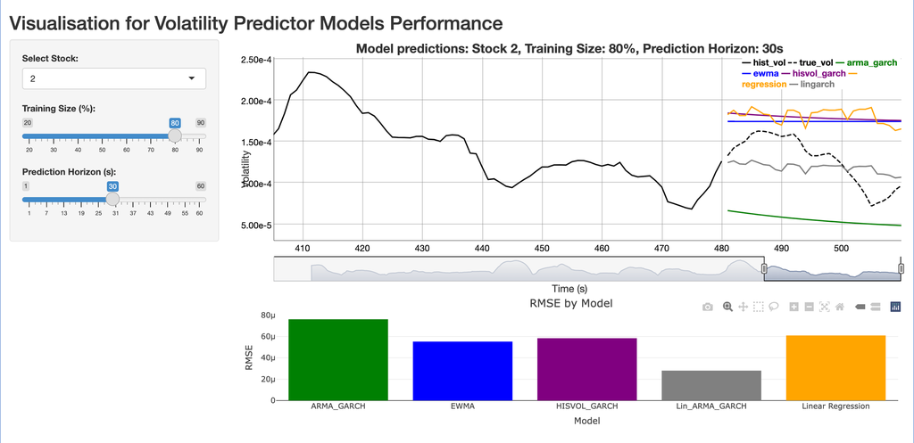

Shiny App Screenshot

## 9.9 Code for Clustering

The below code chunk clusters the stock data over 40 randomly selected time IDs. This sampling rate can be changed through the ‘number_of_time_IDs’ variable. Volatility and volume traded are used as features, averaged across each time ID per stock.

```r
# SETUP WITH BUCKET NAMES
set.seed(3888)
stock0 = read.csv('./cache/individual_book_train/stock_0.csv')

# Get all time IDs
buckets = unique(stock0$time_id)

# Get all files
files = list.files(path='./cache/individual_book_train')

# CLUSTERING
set.seed(3888)
# Determine random time IDs
number_of_time_IDs = 40
buckets_to_choose = sample(buckets, number_of_time_IDs)

# Setup data frame
data = data.frame(matrix(NA, nrow = 1, ncol = number_of_time_IDs*3))
for (i in 1:length(files)) {
  # Read in file
  file = files[i]
  file = paste('./cache/individual_book_train/', file, sep='', collapse='')
  stock = read.csv(file)

  # Get WAP & Quoted Volume
  stock = mutate(stock, WAP = (bid_price1 * ask_size1 + ask_price1 * bid_size1)/(ask_size1 + bid_size1))
  stock = mutate(stock, quoted_volume = ask_size1 + ask_size2 + bid_size1 + bid_size2)

  # Calculate Log Returns
  log_ret <- list()
  for (i in 1 : length(buckets_to_choose)) {
    sec <- stock %>% filter(time_id == buckets_to_choose[i]) %>% pull(seconds_in_bucket)
    price <- stock %>% filter(time_id == buckets_to_choose[i]) %>% pull(WAP)
    log_r <- log(price[-1] / price[1:(length(price) - 1)])
    log_ret[[i]] <- data.frame(time = sec[-1], log_return = log_r)
    time.no.change <- (1:600)[!(1:600 %in% log_ret[[i]]$time)]
    if (length(time.no.change) > 0) {
      new.df <- data.frame(time = time.no.change, log_return = 0)
      log_ret[[i]] <- rbind(log_ret[[i]], new.df)
      log_ret[[i]] <- log_ret[[i]][order(log_ret[[i]]$time), ]
    }
  }

  # Calculate Volatilities
  temp_df = data.frame(matrix(NA, nrow = 1, ncol = number_of_time_IDs))
    index = i
    vols = list()
    for (i in 1:number_of_time_IDs) {
      x = (i-1) * 30
      window = data.frame(log_ret[i]) %>% filter(time > x & time <= x + 30)
      vol = sd(window$log_return)
      vols = append(vols, vol)
    }

    temp_df[nrow(temp_df) + 1,] = vols
    colnames(temp_df) = 1:number_of_time_IDs

  # Get volumes
  volumes = list()
  for (i in 1:length(buckets_to_choose)) {
    volume = stock %>% filter(time_id == buckets_to_choose[i]) %>% pull(quoted_volume)
    volumes = append(volumes, mean(volume))
  }

  temp_df = temp_df %>%  na.omit()
  temp_df$mean = rowMeans(temp_df)

  # Get WAPs
  waps = list()
  for (i in 1:length(buckets_to_choose)) {
    wap = stock %>% filter(time_id == buckets_to_choose[i]) %>% pull(WAP)
    waps = append(waps, mean(wap))
  }

  # Put into global DF
  row = c(temp_df$mean, volumes, waps)
  data[nrow(data) + 1,] = row
}

# Clean & Label
data = data %>%  na.omit()
rownames(data) = files
colnames(data) = c(paste0('Volatility', 1:number_of_time_IDs), paste0('Volume', 1:number_of_time_IDs), paste0('WAP', 1:number_of_time_IDs))

normalize_data = function(x) {
  return ((x - min(x)) / (max(x) - min(x)))
}

# Normalize each column in the data frame
data_to_cluster = data[c(paste0('Volatility', 1:20), paste0('Volume', 1:20))]
data_to_cluster = as.data.frame(lapply(data_to_cluster, normalize_data))

# Cluster
k = 5
kmeans_result = kmeans(data_to_cluster, centers = k, iter.max = 300)
data$Cluster = kmeans_result$cluster
row_names = rownames(data)
clusters = data.frame(row.names = row_names, Clusters = data$Cluster)

# Write data to cache
write.csv(data, "./cache/clustering_results.csv", row.names=TRUE)
```

## 9.10 Code for Models

The below code details how each model produces its predictions.

```r
# MODELS

# VOLATILITY FUNCTION
calculate_volatility <- function(returns) {
  return(sd(returns, na.rm = TRUE))
}

# GARCH
GARCH_model <- function(train = train_data, n_ahead) {

  train <- train[complete.cases(train$log_r), ]

     spec <- ugarchspec(variance.model = list(model = "sGARCH", garchOrder = c(1, 1)), mean.model = list(armaOrder = c(1, 1)), distribution.model = "norm")

     model <- ugarchfit(spec = spec, data = train$log_r, solver = 'hybrid')

     forecast <- ugarchforecast(model, n.ahead = n_ahead)

  predicted_volatility <- forecast@forecast$sigmaFor

     return(predicted_volatility)

}

# HISVOL GARCH
HISVOL_GARCH <- function(train = train_data, n_ahead) {

    train <- train[complete.cases(train$log_r), ]
    N <- length(train$log_r)

    # historical volatility
    log_return_squared <- train$log_r^2
    sigma_values <- sqrt(rollapply(log_return_squared, N, mean, align="right", na.rm = TRUE))
    hisvol_forecast <- mean(tail(sigma_values, N), na.rm = TRUE)

    # fit GARCH model
    garch_spec <- ugarchspec(variance.model = list(model = "sGARCH", garchOrder = c(1, 1)),
                             mean.model = list(armaOrder = c(1, 1), include.mean = TRUE),
                             distribution.model = "norm")


    garch_fit <- ugarchfit(spec = garch_spec, data = train$log_r, solver = "hybrid", solver.control = list(tol = 1e-08, maxiter = 2000))
    garch_forecast <- ugarchforecast(garch_fit, n.ahead = n_ahead)

    # calculate historical volatility and GARCH forecast
    lambda <-  0.5#-3.9
    hisvol_garch_forecast <- lambda * hisvol_forecast + (1 - lambda) * as.numeric(garch_forecast@forecast$sigmaFor)

    return(hisvol_garch_forecast)
}

# REGRESSION
regression_model = function(train_data, test_data) {
  # Contract the simple linear regression model for 'Volatility&log_return'
  model_VL <- lm(volatility ~ log_r, data = train_data)
  predictions_VL <- predict(model_VL, newdata = test_data)
  return(predictions_VL) # returns predicted volatility and accuracy measure
}

#EWMA
ewma_model = function(stockdata, lambda=0.9) {

  ## get training data##
  train <- stockdata

  # there are some NA values in training data provided... CLEAN
  train_clean <- subset(train, !(is.na(train$volatility)))

  vol_vector = movavg(train_clean$volatility, n=length(train_clean$volatility)-1, type='e')

  # final_prediction is the final EWMA calculated from the input return series
  final_prediction <- tail(vol_vector, n=1)

  return(final_prediction) # returns predicted volatility and accuracy measure
}


  # REGRESSION GARCH
regression_GARCH_model = function(train_data, test_data, theta=0.5) {
  # THETA = weighting into regression
  # Contract the simple linear regression model for 'Volatility&log_return'
  model_VL <- lm(volatility ~ log_r, data = train_data)
  predictions_VL <- predict(model_VL, newdata = test_data)

  # GARCH
  train = train_data
  n_ahead = length(test_data$log_r)
  train <- train[complete.cases(train$log_r), ]

     spec <- ugarchspec(variance.model = list(model = "sGARCH", garchOrder = c(1, 1)), mean.model = list(armaOrder = c(1, 1)), distribution.model = "norm")

     model <- ugarchfit(spec = spec, data = train$log_r, solver = 'hybrid')

     forecast <- ugarchforecast(model, n.ahead = n_ahead)

  predicted_volatility <- forecast@forecast$sigmaFor

    final_vals = (predictions_VL * theta) + ((1-theta) * predicted_volatility)
     return(final_vals)
}
```

## 9.11 Code for Model Evaluation

The below code evaluates and produces the RMSE and $R^2$ for each and every model for a random sample of 50 time IDs, changeable in the line with clustering_time_buckets. RMSE and $R^2$ values are aggregated and produced at the end of this chunk. Note, this is very computationally intensive, and takes significant time to run.

```r
####################
# MODEL PREDICTION #
####################
set.seed(3888)
clustering_time_buckets = sample(buckets, 50)
performance = data.frame(matrix(NA, nrow = 1, ncol = 4))

# HOW MANY LOOPS - debug I suggest 1-5, if want to run the whole thing, remove the two break_count loops
break_after = 2
break_count = 0

results = data.frame(matrix(NA, nrow = 1, ncol = 12))
for (x in unique(clusters$Clusters)) {
  files = rownames(clusters %>% filter(Clusters == x))
  print('-----')
  print(x)

  # DEBUGGING
  #if (break_count > break_after) {
  #   break
  #}
  ####

  for (y in 1:length(files)) {
    # DEBUGGING
    break_count = break_count + 1
    #if (break_count > break_after) {
    #  break
    #}
    #####

    # Read in file
    file = files[y]
    file = paste('./cache/individual_book_train/', file, sep='', collapse='')
    data_clean = read.csv(file)

    print(file)

    # WAP Calculation
    data_clean = mutate(data_clean, WAP = (bid_price1 * ask_size1 + ask_price1 * bid_size1)/(ask_size1 + bid_size1))

    # Setup Results vectors
    r2_avgs_emwa = c()
    r2_avgs_linreg = c()
    r2_avgs_armagarch = c()
    r2_avgs_hisvol = c()
    r2_avgs_lingarch = c()

    rmse_avgs_emwa = c()
    rmse_avgs_linreg = c()
    rmse_avgs_armagarch = c()
    rmse_avgs_hisvol = c()
    rmse_avgs_lingarch = c()

    #GET DATA LOG RETURNS ALL 0-599 SECONDS
    log_ret <- list()
    for (j in 1:length(clustering_time_buckets)) {
      data = data_clean %>% filter(time_id == clustering_time_buckets[j])
      for (i in 1:599) {
        if (dim(data %>% filter(seconds_in_bucket==i))[[1]] == 0) {
          dat = data %>% filter(seconds_in_bucket==(i-1))
          dat$seconds_in_bucket = i
          data = rbind(data, dat)
        }
      }

      data = data %>% arrange(seconds_in_bucket)
      window_size = 120 # 2 min to start
      skip = 30 # 30 second increments

      # Add column with the WAP over the interval length so at time T-interval
      interval = 30
      data <- data %>%
        group_by(time_id) %>%
        mutate(WAP_lag = lag(WAP, n = interval, default = first(WAP)),
        WAP_ns_earlier = ifelse(seconds_in_bucket < interval, NA, WAP_lag))

      # Calculate log returns over interval
      data$log_r <- log(data$WAP/data$WAP_ns_earlier)
      data$volatility <- rollapply(data$log_r, width = 30, FUN = calculate_volatility, by = 1, fill = NA, align = "right")

      ts_cv = createTimeSlices(1:nrow(data), initialWindow = window_size, skip = skip, fixedWindow = FALSE)

      # Segment the data and train/test
      r2_emwa = c()
      r2_linreg = c()
      r2_armagarch = c()
      r2_hisvol = c()
      r2_lingarch = c()

      rmse_emwa = c()
      rmse_linreg = c()
      rmse_armagarch = c()
      rmse_hisvol = c()
      rmse_lingarch = c()

      for(i in 1:length(ts_cv[[1]])){
        train_index = ts_cv[[1]][[i]]
        test_index = seq(train_index[[length(train_index)]] + 1, min(train_index[[length(train_index)]] + skip, dim(data)[[1]]))

        train_data = data[train_index, ]
        test_data = data[test_index, ]

        # Model predictions

        predictions_hisvol = HISVOL_GARCH(train = train_data, n_ahead = length(test_data$log_r))

        predictions_ewma = ewma_model(stockdata = train_data)

        predictions_armagarch = GARCH_model(train = train_data, n_ahead = length(test_data$log_r))

        predictions_linreg = regression_model(train_data, test_data)

        predictions_lingarch = regression_GARCH_model(train_data, test_data)

        # Accuracy Measures
        test_data = test_data[complete.cases(test_data$volatility), ]

        # EWMA
        predictions_ewma = rep(predictions_ewma, times=length(test_data$volatility))
        #print(predictions_ewma_r)
        r2_calc = cor(predictions_ewma, test_data$volatility)^2
        r2_emwa = c(r2_emwa, r2_calc)
        MSE = mean((test_data$volatility - predictions_ewma)^2)
        rmse_calc = sqrt(MSE)
        rmse_emwa = c(rmse_emwa, rmse_calc)


        #LIN REG
        if (length(predictions_linreg) == 1) {
          predictions_linreg = rep(predictions_linreg, times = length(test_data))
          r2_calc = cor(predictions_linreg, test_data$volatility)^2

          MSE = mean((test_data$volatility - predictions_linreg)^2)
          rmse_calc = sqrt(MSE)

          r2_linreg = c(r2_linreg, r2_calc)
          rmse_linreg = c(rmse_linreg, rmse_calc)

        } else {
          r2_calc = cor(predictions_linreg, test_data$volatility)^2

          MSE = mean((test_data$volatility - predictions_linreg)^2)
          rmse_calc = sqrt(MSE)

          r2_linreg = c(r2_linreg, r2_calc)
          rmse_linreg = c(rmse_linreg, rmse_calc)
        }

        #ARMA GARCH
        if (length(predictions_armagarch) == 1) {
          r2_calc = NA
          rmse_calc = sqrt(test_data$volatility[[1]] - predictions_armagarch)
          r2_armagarch = c(r2_armagarch, r2_calc)
          rmse_armagarch = c(rmse_armagarch, rmse_calc)

        } else {

          r2_calc = cor(predictions_armagarch, test_data$volatility)^2

          MSE = mean((test_data$volatility - predictions_armagarch)^2)
          rmse_calc = sqrt(MSE)

          r2_armagarch = c(r2_armagarch, r2_calc)
          rmse_armagarch = c(rmse_armagarch, rmse_calc)
        }

        #HISVOL GARCH
        if (length(predictions_hisvol) == 1) {
          r2_calc = NA
          rmse_calc = sqrt(test_data$volatility[[1]] - predictions_hisvol)
          r2_hisvol = c(r2_hisvol, r2_calc)
          rmse_hisvol = c(rmse_hisvol, rmse_calc)

        } else {

          r2_calc = cor(predictions_hisvol, test_data$volatility)^2

          MSE = mean((test_data$volatility - predictions_hisvol)^2)
          rmse_calc = sqrt(MSE)

          r2_hisvol = c(r2_hisvol, r2_calc)
          rmse_hisvol = c(rmse_hisvol, rmse_calc)
        }

        #LINGARCH GARCH
        if (length(predictions_lingarch) == 1) {
          r2_calc = NA
          rmse_calc = sqrt(test_data$volatility[[1]] - predictions_lingarch)
          r2_lingarch = c(r2_lingarch, r2_calc)
          rmse_lingarch = c(rmse_lingarch, rmse_calc)

        } else {

          r2_calc = cor(predictions_lingarch, test_data$volatility)^2

          MSE = mean((test_data$volatility - predictions_lingarch)^2)
          rmse_calc = sqrt(MSE)

          r2_lingarch = c(r2_lingarch, r2_calc)
          rmse_lingarch = c(rmse_lingarch, rmse_calc)
        }


      }

      r2_avgs_emwa = c(r2_avgs_emwa, mean(r2_emwa, na.rm = TRUE))
      rmse_avgs_emwa = c(rmse_avgs_emwa, mean(rmse_emwa, na.rm = TRUE))

      r2_avgs_linreg = c(r2_avgs_linreg, mean(r2_linreg, na.rm = TRUE))
      rmse_avgs_linreg = c(rmse_avgs_linreg, mean(rmse_linreg, na.rm = TRUE))

      r2_avgs_armagarch = c(r2_avgs_armagarch, mean(r2_armagarch, na.rm = TRUE))
      rmse_avgs_armagarch = c(rmse_avgs_armagarch, mean(rmse_armagarch, na.rm = TRUE))

      r2_avgs_hisvol = c(r2_avgs_hisvol, mean(r2_hisvol, na.rm = TRUE))
      rmse_avgs_hisvol = c(rmse_avgs_hisvol, mean(rmse_hisvol, na.rm = TRUE))

      r2_avgs_lingarch = c(r2_avgs_lingarch, mean(r2_lingarch, na.rm = TRUE))
      rmse_avgs_lingarch = c(rmse_avgs_lingarch, mean(rmse_lingarch, na.rm = TRUE))

    }

    row = c(x, file, mean(r2_avgs_emwa, na.rm = TRUE), mean(rmse_avgs_emwa, na.rm = TRUE),
            mean(r2_avgs_linreg, na.rm = TRUE), mean(rmse_avgs_linreg, na.rm = TRUE),
            mean(r2_avgs_armagarch, na.rm = TRUE), mean(rmse_avgs_armagarch, na.rm = TRUE),
            mean(r2_avgs_hisvol, na.rm = TRUE), mean(rmse_avgs_hisvol, na.rm = TRUE),
            mean(r2_avgs_lingarch, na.rm = TRUE), mean(rmse_avgs_lingarch, na.rm = TRUE))
    results[nrow(results) + 1,] = row
  }
  colnames(results) = c('Cluster', 'Stock', 'R2_EWMA', 'RMSE_EWMA',
                            'R2_LinReg', 'RMSE_LinReg',
                            'R2_Armagarch', 'RMSE_Armagarch',
                        'R2_Hisvol', 'RMSE_Hisvol',
                        'R2_Lingarch', 'RMSE_Lingarch')
}
write.csv(results, "./cache/data_results.csv", row.names=TRUE)
```